# Assignment7

#### Machine Learning Assignment 7

#### Atsu Atakpa

```python
#import libraries
import pandas as pd
import pandas.io.sql
import pyodbc
import numpy as np
import matplotlib.pyplot as plt
#matplotlib.style.use('ggplot')
import datetime
from dateutil.parser import parse
%matplotlib inline

import missingno as msno
```

Load the transaction data set https://www.kaggle.com/xvivancos/transactions-from-a-bakery/version/1

```python
#Reading the data in
bread = pd.read_csv('C:/Users/atsua/OneDrive/Documents/SMU/6. Machine Learning/Assignment 7/BreadBasket_DMS.csv',delimiter = ',')
bread.tail(5)
```

|  | Date | Time | Transaction | Item |
| --- | --- | --- | --- | --- |
| 21288 | 2017-04-09 | 14:32:58 | 9682 | Coffee |
| 21289 | 2017-04-09 | 14:32:58 | 9682 | Tea |
| 21290 | 2017-04-09 | 14:57:06 | 9683 | Coffee |
| 21291 | 2017-04-09 | 14:57:06 | 9683 | Pastry |
| 21292 | 2017-04-09 | 15:04:24 | 9684 | Smoothies |

```python
# Converting the Date and Time field and splitting them.

#datetime.datetime.strptime(bread.Date,'%Y-%m-%d')
bread['gg'] = [datetime.datetime.strptime(x,'%Y-%m-%d')for x in bread.Date]
bread['tt'] = [datetime.datetime.strptime(x,"%H:%M:%S")for x in bread.Time]
bread['minute'] = bread['tt'].dt.minute
bread['hour'] = bread['tt'].dt.hour
bread['sec'] = bread['tt'].dt.second
bread['Week_Day_name'] = bread['gg'].dt.weekday_name
bread['year'] = bread['gg'].dt.year
bread['month'] = bread['gg'].dt.month
bread['count'] = 1
bread.head()
```

|  | Date | Time | Transaction | Item | gg | tt | minute | hour | sec | Week_Day_name | year | month | count |
| --- | --- | --- | --- | --- | --- | --- | --- | --- | --- | --- | --- | --- | --- |
| 0 | 2016-10-30 | 09:58:11 | 1 | Bread | 2016-10-30 | 1900-01-01 09:58:11 | 58 | 9 | 11 | Sunday | 2016 | 10 | 1 |
| 1 | 2016-10-30 | 10:05:34 | 2 | Scandinavian | 2016-10-30 | 1900-01-01 10:05:34 | 5 | 10 | 34 | Sunday | 2016 | 10 | 1 |
| 2 | 2016-10-30 | 10:05:34 | 2 | Scandinavian | 2016-10-30 | 1900-01-01 10:05:34 | 5 | 10 | 34 | Sunday | 2016 | 10 | 1 |
| 3 | 2016-10-30 | 10:07:57 | 3 | Hot chocolate | 2016-10-30 | 1900-01-01 10:07:57 | 7 | 10 | 57 | Sunday | 2016 | 10 | 1 |
| 4 | 2016-10-30 | 10:07:57 | 3 | Jam | 2016-10-30 | 1900-01-01 10:07:57 | 7 | 10 | 57 | Sunday | 2016 | 10 | 1 |

### Part A Describe the bakery

```python
print("Description of Date",bread.Date.describe())
print("Description of Time", bread.Time.describe())
print("Description of Transactions",bread.Transaction.describe())
print("Description of Items", bread.Item.describe())
```

```
Description of Date count          21293
unique           159
top       2017-02-04
freq             302
Name: Date, dtype: object
Description of Time count        21293
unique        8240
top       12:07:39
freq            16
Name: Time, dtype: object
Description of Transactions count    21293.000000
mean      4951.990889
std       2787.758400
min          1.000000
25%       2548.000000
50%       5067.000000
75%       7329.000000
max       9684.000000
Name: Transaction, dtype: float64
Description of Items count      21293
unique        95
top       Coffee
freq        5471
Name: Item, dtype: object
```

### How many transactions are there?

```python
bread.info()
```

```
<class 'pandas.core.frame.DataFrame'>
RangeIndex: 21293 entries, 0 to 21292
Data columns (total 13 columns):
Date             21293 non-null object
Time             21293 non-null object
Transaction      21293 non-null int64
Item             21293 non-null object
gg               21293 non-null datetime64[ns]
tt               21293 non-null datetime64[ns]
minute           21293 non-null int64
hour             21293 non-null int64
sec              21293 non-null int64
Week_Day_name    21293 non-null object
year             21293 non-null int64
month            21293 non-null int64
count            21293 non-null int64
dtypes: datetime64[ns](2), int64(7), object(4)
memory usage: 2.1+ MB
```

```python
bread.Transaction.value_counts()
```

```
6474    12
6716    11
6279    11
6412    11
8835    10
9447    10
6045    10
3673    10
7245    10
3799     9
6290     9
6519     9
6038     9
9534     9
3917     8
```

[output cut: 47 more lines]

###### The total number of transactions were 9531

### What time does their day start?

```python
bread_start = bread.sort_values(by=['Week_Day_name','Time'])
bread_start.head(5)
```

|  | Date | Time | Transaction | Item | gg | tt | minute | hour | sec | Week_Day_name | year | month | count |
| --- | --- | --- | --- | --- | --- | --- | --- | --- | --- | --- | --- | --- | --- |
| 903 | 2016-11-04 | 07:32:33 | 437 | Medialuna | 2016-11-04 | 1900-01-01 07:32:33 | 32 | 7 | 33 | Friday | 2016 | 11 | 1 |
| 18976 | 2017-03-24 | 08:01:27 | 8663 | Cookies | 2017-03-24 | 1900-01-01 08:01:27 | 1 | 8 | 27 | Friday | 2017 | 3 | 1 |
| 18977 | 2017-03-24 | 08:01:27 | 8663 | Brownie | 2017-03-24 | 1900-01-01 08:01:27 | 1 | 8 | 27 | Friday | 2017 | 3 | 1 |
| 18978 | 2017-03-24 | 08:01:27 | 8663 | Coffee | 2017-03-24 | 1900-01-01 08:01:27 | 1 | 8 | 27 | Friday | 2017 | 3 | 1 |
| 17188 | 2017-03-10 | 08:05:41 | 7854 | Coffee | 2017-03-10 | 1900-01-01 08:05:41 | 5 | 8 | 41 | Friday | 2017 | 3 | 1 |

### What time does their day end?

```python
bread_start = pd.crosstab([ bread_start['Time']],
                       bread_start.Date)
print (bread_start)
```

```
Date      2016-10-30  2016-10-31  2016-11-01  2016-11-02  2016-11-03  \
Time
01:21:05           0           0           0           0           0
07:29:57           0           0           0           0           0
07:32:33           0           0           0           0           0
07:39:27           0           0           0           0           0
07:42:27           0           0           0           0           0
07:44:17           0           0           0           0           0
07:46:50           0           0           0           0           2
07:49:01           0           0           0           0           0
07:49:40           0           0           0           0           0
07:50:50           0           0           0           0           2
07:51:20           0           0           2           0           0
07:54:15           0           0           0           0           0
07:56:19           0           0           0           0           0
07:58:41           0           0           0           0           0
07:58:43           0           0           0           0           0
07:58:54           0           0           0           0           0
07:59:55           0           0           0           0           0
08:01:06           0           0           0           0           0
08:01:08           0           0           0           0           2
08:01:27           0           0           0           0           0
08:01:35           0           0           0           0           0
08:02:20           0           0           0           3           0
08:04:48           0           0           0           0           0
08:04:56           0           0           0           0           0
08:05:03           0           0           0           2           0
08:05:04           0           0           0           0           0
08:05:41           0           0           0           0           0
08:06:09           0           0           0           0           0
08:06:20           0           0           0           0           0
08:06:41           0           0           0           0           0
...              ...         ...         ...         ...         ...
19:56:24           0           0           0           0           0
19:57:04           0           0           0           0           0
19:59:23           0           0           0           0           0
20:00:47           0           0           0           0           0
20:08:19           0           0           0           0           0
20:11:01           0           0           0           0           0
20:12:57           0           0           0           0           0
```

[output cut: 266 more lines]

```
20:46:29           0
21:42:13           0
21:43:15           0
22:15:55           0
22:41:09           0
22:43:06           0
22:45:51           0
22:47:27           0
22:48:52           0
22:56:43           0
23:20:54           0
23:29:03           0
23:38:41           0

[8240 rows x 159 columns]
```

```python
#bread.pivot_table(index = "Time", columns = "Date", aggfunc = 'mean' )
```

#### Result

From the cross functional table above, it appears that the bakery started '01:21:05'

### What time does their day end?

```python
bread_end = bread.sort_values(by=['Time'], ascending = False)
bread_end = pd.crosstab([ bread_end['Time']],bread_end.Date)
print (bread_end)
```

```
Date      2016-10-30  2016-10-31  2016-11-01  2016-11-02  2016-11-03  \
Time
01:21:05           0           0           0           0           0
07:29:57           0           0           0           0           0
07:32:33           0           0           0           0           0
07:39:27           0           0           0           0           0
07:42:27           0           0           0           0           0
07:44:17           0           0           0           0           0
07:46:50           0           0           0           0           2
07:49:01           0           0           0           0           0
07:49:40           0           0           0           0           0
07:50:50           0           0           0           0           2
07:51:20           0           0           2           0           0
07:54:15           0           0           0           0           0
07:56:19           0           0           0           0           0
07:58:41           0           0           0           0           0
07:58:43           0           0           0           0           0
07:58:54           0           0           0           0           0
07:59:55           0           0           0           0           0
08:01:06           0           0           0           0           0
08:01:08           0           0           0           0           2
08:01:27           0           0           0           0           0
08:01:35           0           0           0           0           0
08:02:20           0           0           0           3           0
08:04:48           0           0           0           0           0
08:04:56           0           0           0           0           0
08:05:03           0           0           0           2           0
08:05:04           0           0           0           0           0
08:05:41           0           0           0           0           0
08:06:09           0           0           0           0           0
08:06:20           0           0           0           0           0
08:06:41           0           0           0           0           0
...              ...         ...         ...         ...         ...
19:56:24           0           0           0           0           0
19:57:04           0           0           0           0           0
19:59:23           0           0           0           0           0
20:00:47           0           0           0           0           0
20:08:19           0           0           0           0           0
20:11:01           0           0           0           0           0
20:12:57           0           0           0           0           0
```

[output cut: 266 more lines]

```
20:46:29           0
21:42:13           0
21:43:15           0
22:15:55           0
22:41:09           0
22:43:06           0
22:45:51           0
22:47:27           0
22:48:52           0
22:56:43           0
23:20:54           0
23:29:03           0
23:38:41           0

[8240 rows x 159 columns]
```

#### Result

From the cross functional table above, it appears that the bakery started '23:38:41'

# What time is the busiest hour?

```python
busiest_hour = bread.hour.value_counts()
busiest_hour.head(5)
```

```
11    3216
12    3021
13    2776
10    2763
14    2736
Name: hour, dtype: int64
```

Their busiest hour was is at 11am. That was the hour at which they had the most transactions

```python
#bread['DT'] = bread['Date'] + bread['Time']
#bread.head()
```

# How many different things do they sell?

```python
bread.Item.count()
```

```
21293
```

```python
Item_count = bread.Item.unique()
np.shape(Item_count)
```

```
(95,)
```

```python
Item_count
```

```
array(['Bread', 'Scandinavian', 'Hot chocolate', 'Jam', 'Cookies',
       'Muffin', 'Coffee', 'Pastry', 'Medialuna', 'Tea', 'NONE',
       'Tartine', 'Basket', 'Mineral water', 'Farm House', 'Fudge',
       'Juice', "Ella's Kitchen Pouches", 'Victorian Sponge', 'Frittata',
       'Hearty & Seasonal', 'Soup', 'Pick and Mix Bowls', 'Smoothies',
       'Cake', 'Mighty Protein', 'Chicken sand', 'Coke',
       'My-5 Fruit Shoot', 'Focaccia', 'Sandwich', 'Alfajores', 'Eggs',
       'Brownie', 'Dulce de Leche', 'Honey', 'The BART', 'Granola',
       'Fairy Doors', 'Empanadas', 'Keeping It Local', 'Art Tray',
       'Bowl Nic Pitt', 'Bread Pudding', 'Adjustment', 'Truffles',
       'Chimichurri Oil', 'Bacon', 'Spread', 'Kids biscuit', 'Siblings',
       'Caramel bites', 'Jammie Dodgers', 'Tiffin', 'Olum & polenta',
       'Polenta', 'The Nomad', 'Hack the stack', 'Bakewell',
       'Lemon and coconut', 'Toast', 'Scone', 'Crepes', 'Vegan mincepie',
       'Bare Popcorn', 'Muesli', 'Crisps', 'Pintxos', 'Gingerbread syrup',
       'Panatone', 'Brioche and salami', 'Afternoon with the baker',
       'Salad', 'Chicken Stew', 'Spanish Brunch',
       'Raspberry shortbread sandwich', 'Extra Salami or Feta',
       'Duck egg', 'Baguette', "Valentine's card", 'Tshirt',
       'Vegan Feast', 'Postcard', 'Nomad bag', 'Chocolates',
       'Coffee granules ', 'Drinking chocolate spoons ',
       'Christmas common', 'Argentina Night', 'Half slice Monster ',
       'Gift voucher', 'Cherry me Dried fruit', 'Mortimer', 'Raw bars',
       'Tacos/Fajita'], dtype=object)
```

```python
#Removing the NONE from the item count
dd = np.delete(Item_count,[10])
dd
```

```
array(['Bread', 'Scandinavian', 'Hot chocolate', 'Jam', 'Cookies',
       'Muffin', 'Coffee', 'Pastry', 'Medialuna', 'Tea', 'Tartine',
       'Basket', 'Mineral water', 'Farm House', 'Fudge', 'Juice',
       "Ella's Kitchen Pouches", 'Victorian Sponge', 'Frittata',
       'Hearty & Seasonal', 'Soup', 'Pick and Mix Bowls', 'Smoothies',
       'Cake', 'Mighty Protein', 'Chicken sand', 'Coke',
       'My-5 Fruit Shoot', 'Focaccia', 'Sandwich', 'Alfajores', 'Eggs',
       'Brownie', 'Dulce de Leche', 'Honey', 'The BART', 'Granola',
       'Fairy Doors', 'Empanadas', 'Keeping It Local', 'Art Tray',
       'Bowl Nic Pitt', 'Bread Pudding', 'Adjustment', 'Truffles',
       'Chimichurri Oil', 'Bacon', 'Spread', 'Kids biscuit', 'Siblings',
       'Caramel bites', 'Jammie Dodgers', 'Tiffin', 'Olum & polenta',
       'Polenta', 'The Nomad', 'Hack the stack', 'Bakewell',
       'Lemon and coconut', 'Toast', 'Scone', 'Crepes', 'Vegan mincepie',
       'Bare Popcorn', 'Muesli', 'Crisps', 'Pintxos', 'Gingerbread syrup',
       'Panatone', 'Brioche and salami', 'Afternoon with the baker',
       'Salad', 'Chicken Stew', 'Spanish Brunch',
       'Raspberry shortbread sandwich', 'Extra Salami or Feta',
       'Duck egg', 'Baguette', "Valentine's card", 'Tshirt',
       'Vegan Feast', 'Postcard', 'Nomad bag', 'Chocolates',
       'Coffee granules ', 'Drinking chocolate spoons ',
       'Christmas common', 'Argentina Night', 'Half slice Monster ',
       'Gift voucher', 'Cherry me Dried fruit', 'Mortimer', 'Raw bars',
       'Tacos/Fajita'], dtype=object)
```

```python
ff = pd.DataFrame(dd)
ff.head(5)
```

|  | 0 |
| --- | --- |
| 0 | Bread |
| 1 | Scandinavian |
| 2 | Hot chocolate |
| 3 | Jam |
| 4 | Cookies |

#### The total number of unique items sold are 94

### Graph of sales by day

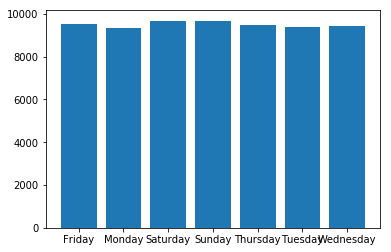

```python
import matplotlib.pyplot as plt

plt.bar(bread.Week_Day_name, bread.Transaction)
plt.show()
```

```python
df_grouped = bread.groupby(by=['Date'])
#df_grouped['Date2']=pd.to_datetime(df_grouped['Date'])
#df_grouped.describe()
```

### Part B Describe the customer

#### How many times do they sell every item?

```python
bread.Item.value_counts()
```

```
Coffee                           5471
Bread                            3325
Tea                              1435
Cake                             1025
Pastry                            856
NONE                              786
Sandwich                          771
Medialuna                         616
Hot chocolate                     590
Cookies                           540
Brownie                           379
Farm House                        374
Muffin                            370
Juice                             369
Alfajores                         369
Soup                              342
Scone                             327
Toast                             318
Scandinavian                      277
Truffles                          193
Coke                              185
Spanish Brunch                    172
Fudge                             159
Baguette                          152
Jam                               149
Tiffin                            146
Mineral water                     136
Jammie Dodgers                    125
Chicken Stew                      123
Hearty & Seasonal                 107
                                 ...
Victorian Sponge                    7
Argentina Night                     7
Crepes                              6
Half slice Monster                  6
Pintxos                             6
Honey                               6
Basket                              6
Lemon and coconut                   6
Mortimer                            5
Panatone                            5
Bare Popcorn                        5
Bread Pudding                       4
Raspberry shortbread sandwich       3
Cherry me Dried fruit               3
Brioche and salami                  3
Caramel bites                       3
Chimichurri Oil                     2
Fairy Doors                         2
Hack the stack                      2
Bowl Nic Pitt                       2
Siblings                            2
Spread                              2
Chicken sand                        1
Adjustment                          1
Raw bars                            1
Olum & polenta                      1
Bacon                               1
Polenta                             1
Gift voucher                        1
The BART                            1
Name: Item, Length: 95, dtype: int64
```

#### What is the relative frequency of sales? (graph)

```python
from scipy import stats

res = stats.relfreq(bread.Transaction, numbins = 25)
```

```python
res
```

```
RelfreqResult(frequency=array([0.02047621, 0.04001315, 0.03991922, 0.04071761, 0.03973137,
       0.03959048, 0.03818156, 0.03888602, 0.03860424, 0.03935566,
       0.04095243, 0.03959048, 0.04132814, 0.04015404, 0.04362936,
       0.0435824 , 0.0463063 , 0.04762128, 0.0457897 , 0.044099  ,
       0.04287794, 0.04095243, 0.04330062, 0.04362936, 0.02071103]), lowerlimit=-200.72916666666666, binsize=403.45833333333326, extrapoints=0)
```

```python
x = res.lowerlimit + np.linspace(0, res.binsize*res.frequency.size,res.frequency.size)
```

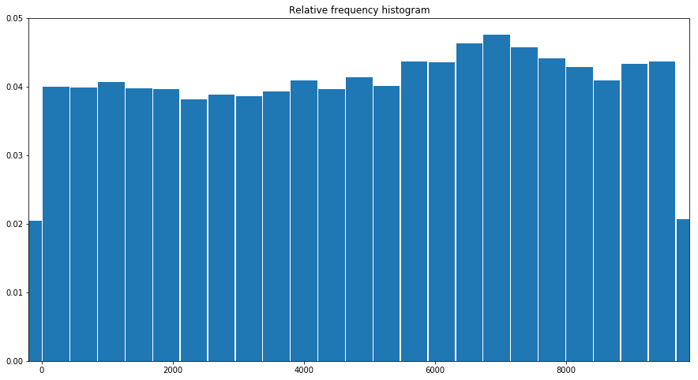

```python
fig = plt.figure(figsize=(15, 8))
ax = fig.add_subplot(1, 1, 1)
ax.bar(x, res.frequency, width=res.binsize)
ax.set_title('Relative frequency histogram')
ax.set_xlim([x.min(), x.max()])
plt.show()
```

#### How often do people buy tea with coffee? How about Coffee and croissant? Coffee and something from the bakery?

## Tea with Coffee

```python
T_C = bread[(bread.Item == ('Tea')) | (bread.Item == 'Coffee')]
T_C.head(5)
```

|  | Date | Time | Transaction | Item | gg | tt | minute | hour | sec | Week_Day_name | year | month | count |
| --- | --- | --- | --- | --- | --- | --- | --- | --- | --- | --- | --- | --- | --- |
| 7 | 2016-10-30 | 10:13:03 | 5 | Coffee | 2016-10-30 | 1900-01-01 10:13:03 | 13 | 10 | 3 | Sunday | 2016 | 10 | 1 |
| 15 | 2016-10-30 | 10:19:12 | 7 | Coffee | 2016-10-30 | 1900-01-01 10:19:12 | 19 | 10 | 12 | Sunday | 2016 | 10 | 1 |
| 16 | 2016-10-30 | 10:19:12 | 7 | Tea | 2016-10-30 | 1900-01-01 10:19:12 | 19 | 10 | 12 | Sunday | 2016 | 10 | 1 |
| 28 | 2016-10-30 | 10:30:14 | 12 | Coffee | 2016-10-30 | 1900-01-01 10:30:14 | 30 | 10 | 14 | Sunday | 2016 | 10 | 1 |
| 31 | 2016-10-30 | 10:30:14 | 12 | Tea | 2016-10-30 | 1900-01-01 10:30:14 | 30 | 10 | 14 | Sunday | 2016 | 10 | 1 |

```python
df2 = T_C.groupby(by=['Transaction'])
df2.head(5)
```

|  | Date | Time | Transaction | Item | gg | tt | minute | hour | sec | Week_Day_name | year | month | count |
| --- | --- | --- | --- | --- | --- | --- | --- | --- | --- | --- | --- | --- | --- |
| 7 | 2016-10-30 | 10:13:03 | 5 | Coffee | 2016-10-30 | 1900-01-01 10:13:03 | 13 | 10 | 3 | Sunday | 2016 | 10 | 1 |
| 15 | 2016-10-30 | 10:19:12 | 7 | Coffee | 2016-10-30 | 1900-01-01 10:19:12 | 19 | 10 | 12 | Sunday | 2016 | 10 | 1 |
| 16 | 2016-10-30 | 10:19:12 | 7 | Tea | 2016-10-30 | 1900-01-01 10:19:12 | 19 | 10 | 12 | Sunday | 2016 | 10 | 1 |
| 28 | 2016-10-30 | 10:30:14 | 12 | Coffee | 2016-10-30 | 1900-01-01 10:30:14 | 30 | 10 | 14 | Sunday | 2016 | 10 | 1 |
| 31 | 2016-10-30 | 10:30:14 | 12 | Tea | 2016-10-30 | 1900-01-01 10:30:14 | 30 | 10 | 14 | Sunday | 2016 | 10 | 1 |
| 34 | 2016-10-30 | 10:31:24 | 13 | Coffee | 2016-10-30 | 1900-01-01 10:31:24 | 31 | 10 | 24 | Sunday | 2016 | 10 | 1 |
| 44 | 2016-10-30 | 10:37:08 | 16 | Coffee | 2016-10-30 | 1900-01-01 10:37:08 | 37 | 10 | 8 | Sunday | 2016 | 10 | 1 |
| 51 | 2016-10-30 | 10:49:29 | 21 | Coffee | 2016-10-30 | 1900-01-01 10:49:29 | 49 | 10 | 29 | Sunday | 2016 | 10 | 1 |
| 52 | 2016-10-30 | 10:49:29 | 21 | Coffee | 2016-10-30 | 1900-01-01 10:49:29 | 49 | 10 | 29 | Sunday | 2016 | 10 | 1 |
| 62 | 2016-10-30 | 11:03:24 | 28 | Coffee | 2016-10-30 | 1900-01-01 11:03:24 | 3 | 11 | 24 | Sunday | 2016 | 10 | 1 |
| 71 | 2016-10-30 | 11:22:49 | 33 | Coffee | 2016-10-30 | 1900-01-01 11:22:49 | 22 | 11 | 49 | Sunday | 2016 | 10 | 1 |
| 72 | 2016-10-30 | 11:25:45 | 34 | Coffee | 2016-10-30 | 1900-01-01 11:25:45 | 25 | 11 | 45 | Sunday | 2016 | 10 | 1 |
| 76 | 2016-10-30 | 11:33:08 | 36 | Tea | 2016-10-30 | 1900-01-01 11:33:08 | 33 | 11 | 8 | Sunday | 2016 | 10 | 1 |
| 78 | 2016-10-30 | 11:37:10 | 37 | Coffee | 2016-10-30 | 1900-01-01 11:37:10 | 37 | 11 | 10 | Sunday | 2016 | 10 | 1 |
| 82 | 2016-10-30 | 11:42:40 | 38 | Tea | 2016-10-30 | 1900-01-01 11:42:40 | 42 | 11 | 40 | Sunday | 2016 | 10 | 1 |
| 87 | 2016-10-30 | 11:55:51 | 40 | Coffee | 2016-10-30 | 1900-01-01 11:55:51 | 55 | 11 | 51 | Sunday | 2016 | 10 | 1 |
| 91 | 2016-10-30 | 11:57:45 | 42 | Tea | 2016-10-30 | 1900-01-01 11:57:45 | 57 | 11 | 45 | Sunday | 2016 | 10 | 1 |
| 94 | 2016-10-30 | 12:05:47 | 44 | Coffee | 2016-10-30 | 1900-01-01 12:05:47 | 5 | 12 | 47 | Sunday | 2016 | 10 | 1 |
| 96 | 2016-10-30 | 12:08:36 | 45 | Coffee | 2016-10-30 | 1900-01-01 12:08:36 | 8 | 12 | 36 | Sunday | 2016 | 10 | 1 |
| 99 | 2016-10-30 | 12:09:04 | 46 | Coffee | 2016-10-30 | 1900-01-01 12:09:04 | 9 | 12 | 4 | Sunday | 2016 | 10 | 1 |
| 105 | 2016-10-30 | 12:17:02 | 48 | Coffee | 2016-10-30 | 1900-01-01 12:17:02 | 17 | 12 | 2 | Sunday | 2016 | 10 | 1 |
| 106 | 2016-10-30 | 12:23:01 | 49 | Coffee | 2016-10-30 | 1900-01-01 12:23:01 | 23 | 12 | 1 | Sunday | 2016 | 10 | 1 |
| 107 | 2016-10-30 | 12:23:01 | 49 | Coffee | 2016-10-30 | 1900-01-01 12:23:01 | 23 | 12 | 1 | Sunday | 2016 | 10 | 1 |
| 115 | 2016-10-30 | 12:38:06 | 55 | Coffee | 2016-10-30 | 1900-01-01 12:38:06 | 38 | 12 | 6 | Sunday | 2016 | 10 | 1 |
| 116 | 2016-10-30 | 12:38:06 | 55 | Tea | 2016-10-30 | 1900-01-01 12:38:06 | 38 | 12 | 6 | Sunday | 2016 | 10 | 1 |
| 118 | 2016-10-30 | 12:39:27 | 56 | Coffee | 2016-10-30 | 1900-01-01 12:39:27 | 39 | 12 | 27 | Sunday | 2016 | 10 | 1 |
| 123 | 2016-10-30 | 12:59:29 | 58 | Tea | 2016-10-30 | 1900-01-01 12:59:29 | 59 | 12 | 29 | Sunday | 2016 | 10 | 1 |
| 125 | 2016-10-30 | 13:02:04 | 59 | Tea | 2016-10-30 | 1900-01-01 13:02:04 | 2 | 13 | 4 | Sunday | 2016 | 10 | 1 |
| 128 | 2016-10-30 | 13:14:04 | 60 | Coffee | 2016-10-30 | 1900-01-01 13:14:04 | 14 | 13 | 4 | Sunday | 2016 | 10 | 1 |
| 130 | 2016-10-30 | 13:14:04 | 60 | Coffee | 2016-10-30 | 1900-01-01 13:14:04 | 14 | 13 | 4 | Sunday | 2016 | 10 | 1 |
| ... | ... | ... | ... | ... | ... | ... | ... | ... | ... | ... | ... | ... | ... |
| 21191 | 2017-04-08 | 16:06:48 | 9628 | Coffee | 2017-04-08 | 1900-01-01 16:06:48 | 6 | 16 | 48 | Saturday | 2017 | 4 | 1 |
| 21192 | 2017-04-08 | 16:06:48 | 9628 | Tea | 2017-04-08 | 1900-01-01 16:06:48 | 6 | 16 | 48 | Saturday | 2017 | 4 | 1 |
| 21196 | 2017-04-08 | 16:16:03 | 9630 | Coffee | 2017-04-08 | 1900-01-01 16:16:03 | 16 | 16 | 3 | Saturday | 2017 | 4 | 1 |
| 21199 | 2017-04-08 | 16:25:09 | 9632 | Coffee | 2017-04-08 | 1900-01-01 16:25:09 | 25 | 16 | 9 | Saturday | 2017 | 4 | 1 |
| 21203 | 2017-04-08 | 16:30:32 | 9634 | Coffee | 2017-04-08 | 1900-01-01 16:30:32 | 30 | 16 | 32 | Saturday | 2017 | 4 | 1 |
| 21206 | 2017-04-08 | 16:30:32 | 9634 | Coffee | 2017-04-08 | 1900-01-01 16:30:32 | 30 | 16 | 32 | Saturday | 2017 | 4 | 1 |
| 21207 | 2017-04-08 | 16:37:48 | 9635 | Coffee | 2017-04-08 | 1900-01-01 16:37:48 | 37 | 16 | 48 | Saturday | 2017 | 4 | 1 |
| 21210 | 2017-04-08 | 16:40:08 | 9636 | Tea | 2017-04-08 | 1900-01-01 16:40:08 | 40 | 16 | 8 | Saturday | 2017 | 4 | 1 |
| 21222 | 2017-04-09 | 09:29:57 | 9649 | Coffee | 2017-04-09 | 1900-01-01 09:29:57 | 29 | 9 | 57 | Sunday | 2017 | 4 | 1 |
| 21225 | 2017-04-09 | 10:03:08 | 9650 | Coffee | 2017-04-09 | 1900-01-01 10:03:08 | 3 | 10 | 8 | Sunday | 2017 | 4 | 1 |
| 21229 | 2017-04-09 | 10:08:23 | 9651 | Coffee | 2017-04-09 | 1900-01-01 10:08:23 | 8 | 10 | 23 | Sunday | 2017 | 4 | 1 |
| 21231 | 2017-04-09 | 10:39:07 | 9653 | Coffee | 2017-04-09 | 1900-01-01 10:39:07 | 39 | 10 | 7 | Sunday | 2017 | 4 | 1 |
| 21236 | 2017-04-09 | 11:14:28 | 9655 | Tea | 2017-04-09 | 1900-01-01 11:14:28 | 14 | 11 | 28 | Sunday | 2017 | 4 | 1 |
| 21237 | 2017-04-09 | 11:17:43 | 9656 | Coffee | 2017-04-09 | 1900-01-01 11:17:43 | 17 | 11 | 43 | Sunday | 2017 | 4 | 1 |
| 21239 | 2017-04-09 | 11:22:01 | 9657 | Coffee | 2017-04-09 | 1900-01-01 11:22:01 | 22 | 11 | 1 | Sunday | 2017 | 4 | 1 |
| 21240 | 2017-04-09 | 11:30:22 | 9658 | Coffee | 2017-04-09 | 1900-01-01 11:30:22 | 30 | 11 | 22 | Sunday | 2017 | 4 | 1 |
| 21243 | 2017-04-09 | 11:31:15 | 9659 | Tea | 2017-04-09 | 1900-01-01 11:31:15 | 31 | 11 | 15 | Sunday | 2017 | 4 | 1 |
| 21247 | 2017-04-09 | 11:40:10 | 9664 | Coffee | 2017-04-09 | 1900-01-01 11:40:10 | 40 | 11 | 10 | Sunday | 2017 | 4 | 1 |
| 21248 | 2017-04-09 | 11:40:10 | 9664 | Coffee | 2017-04-09 | 1900-01-01 11:40:10 | 40 | 11 | 10 | Sunday | 2017 | 4 | 1 |
| 21250 | 2017-04-09 | 11:59:57 | 9665 | Coffee | 2017-04-09 | 1900-01-01 11:59:57 | 59 | 11 | 57 | Sunday | 2017 | 4 | 1 |
| 21253 | 2017-04-09 | 12:01:07 | 9666 | Coffee | 2017-04-09 | 1900-01-01 12:01:07 | 1 | 12 | 7 | Sunday | 2017 | 4 | 1 |
| 21259 | 2017-04-09 | 12:07:57 | 9668 | Tea | 2017-04-09 | 1900-01-01 12:07:57 | 7 | 12 | 57 | Sunday | 2017 | 4 | 1 |
| 21264 | 2017-04-09 | 12:31:28 | 9672 | Coffee | 2017-04-09 | 1900-01-01 12:31:28 | 31 | 12 | 28 | Sunday | 2017 | 4 | 1 |
| 21269 | 2017-04-09 | 12:32:03 | 9673 | Coffee | 2017-04-09 | 1900-01-01 12:32:03 | 32 | 12 | 3 | Sunday | 2017 | 4 | 1 |
| 21271 | 2017-04-09 | 13:04:08 | 9674 | Coffee | 2017-04-09 | 1900-01-01 13:04:08 | 4 | 13 | 8 | Sunday | 2017 | 4 | 1 |
| 21276 | 2017-04-09 | 13:49:21 | 9678 | Coffee | 2017-04-09 | 1900-01-01 13:49:21 | 49 | 13 | 21 | Sunday | 2017 | 4 | 1 |
| 21283 | 2017-04-09 | 14:30:09 | 9681 | Tea | 2017-04-09 | 1900-01-01 14:30:09 | 30 | 14 | 9 | Sunday | 2017 | 4 | 1 |
| 21288 | 2017-04-09 | 14:32:58 | 9682 | Coffee | 2017-04-09 | 1900-01-01 14:32:58 | 32 | 14 | 58 | Sunday | 2017 | 4 | 1 |
| 21289 | 2017-04-09 | 14:32:58 | 9682 | Tea | 2017-04-09 | 1900-01-01 14:32:58 | 32 | 14 | 58 | Sunday | 2017 | 4 | 1 |
| 21290 | 2017-04-09 | 14:57:06 | 9683 | Coffee | 2017-04-09 | 1900-01-01 14:57:06 | 57 | 14 | 6 | Sunday | 2017 | 4 | 1 |

6906 rows × 13 columns

```python
#df1 = DataFrame
T_C.pivot_table(index="Transaction",columns="Item", aggfunc="count")
```

| Item Transaction | Date Coffee | Date Tea | Time Coffee | Time Tea | Week_Day_name Coffee | Week_Day_name Tea | count Coffee | count Tea | gg Coffee | gg Tea | ... | minute Coffee | minute Tea | month Coffee | month Tea | sec Coffee | sec Tea | tt Coffee | tt Tea | year Coffee | year Tea |
| --- | --- | --- | --- | --- | --- | --- | --- | --- | --- | --- | --- | --- | --- | --- | --- | --- | --- | --- | --- | --- | --- |
| 5 | 1.0 | NaN | 1.0 | NaN | 1.0 | NaN | 1.0 | NaN | 1.0 | NaN | ... | 1.0 | NaN | 1.0 | NaN | 1.0 | NaN | 1.0 | NaN | 1.0 | NaN |
| 7 | 1.0 | 1.0 | 1.0 | 1.0 | 1.0 | 1.0 | 1.0 | 1.0 | 1.0 | 1.0 | ... | 1.0 | 1.0 | 1.0 | 1.0 | 1.0 | 1.0 | 1.0 | 1.0 | 1.0 | 1.0 |
| 12 | 1.0 | 1.0 | 1.0 | 1.0 | 1.0 | 1.0 | 1.0 | 1.0 | 1.0 | 1.0 | ... | 1.0 | 1.0 | 1.0 | 1.0 | 1.0 | 1.0 | 1.0 | 1.0 | 1.0 | 1.0 |
| 13 | 1.0 | NaN | 1.0 | NaN | 1.0 | NaN | 1.0 | NaN | 1.0 | NaN | ... | 1.0 | NaN | 1.0 | NaN | 1.0 | NaN | 1.0 | NaN | 1.0 | NaN |
| 16 | 1.0 | NaN | 1.0 | NaN | 1.0 | NaN | 1.0 | NaN | 1.0 | NaN | ... | 1.0 | NaN | 1.0 | NaN | 1.0 | NaN | 1.0 | NaN | 1.0 | NaN |
| 21 | 2.0 | NaN | 2.0 | NaN | 2.0 | NaN | 2.0 | NaN | 2.0 | NaN | ... | 2.0 | NaN | 2.0 | NaN | 2.0 | NaN | 2.0 | NaN | 2.0 | NaN |
| 28 | 1.0 | NaN | 1.0 | NaN | 1.0 | NaN | 1.0 | NaN | 1.0 | NaN | ... | 1.0 | NaN | 1.0 | NaN | 1.0 | NaN | 1.0 | NaN | 1.0 | NaN |
| 33 | 1.0 | NaN | 1.0 | NaN | 1.0 | NaN | 1.0 | NaN | 1.0 | NaN | ... | 1.0 | NaN | 1.0 | NaN | 1.0 | NaN | 1.0 | NaN | 1.0 | NaN |
| 34 | 1.0 | NaN | 1.0 | NaN | 1.0 | NaN | 1.0 | NaN | 1.0 | NaN | ... | 1.0 | NaN | 1.0 | NaN | 1.0 | NaN | 1.0 | NaN | 1.0 | NaN |
| 36 | NaN | 1.0 | NaN | 1.0 | NaN | 1.0 | NaN | 1.0 | NaN | 1.0 | ... | NaN | 1.0 | NaN | 1.0 | NaN | 1.0 | NaN | 1.0 | NaN | 1.0 |
| 37 | 1.0 | NaN | 1.0 | NaN | 1.0 | NaN | 1.0 | NaN | 1.0 | NaN | ... | 1.0 | NaN | 1.0 | NaN | 1.0 | NaN | 1.0 | NaN | 1.0 | NaN |
| 38 | NaN | 1.0 | NaN | 1.0 | NaN | 1.0 | NaN | 1.0 | NaN | 1.0 | ... | NaN | 1.0 | NaN | 1.0 | NaN | 1.0 | NaN | 1.0 | NaN | 1.0 |
| 40 | 1.0 | NaN | 1.0 | NaN | 1.0 | NaN | 1.0 | NaN | 1.0 | NaN | ... | 1.0 | NaN | 1.0 | NaN | 1.0 | NaN | 1.0 | NaN | 1.0 | NaN |
| 42 | NaN | 1.0 | NaN | 1.0 | NaN | 1.0 | NaN | 1.0 | NaN | 1.0 | ... | NaN | 1.0 | NaN | 1.0 | NaN | 1.0 | NaN | 1.0 | NaN | 1.0 |
| 44 | 1.0 | NaN | 1.0 | NaN | 1.0 | NaN | 1.0 | NaN | 1.0 | NaN | ... | 1.0 | NaN | 1.0 | NaN | 1.0 | NaN | 1.0 | NaN | 1.0 | NaN |
| 45 | 1.0 | NaN | 1.0 | NaN | 1.0 | NaN | 1.0 | NaN | 1.0 | NaN | ... | 1.0 | NaN | 1.0 | NaN | 1.0 | NaN | 1.0 | NaN | 1.0 | NaN |
| 46 | 1.0 | NaN | 1.0 | NaN | 1.0 | NaN | 1.0 | NaN | 1.0 | NaN | ... | 1.0 | NaN | 1.0 | NaN | 1.0 | NaN | 1.0 | NaN | 1.0 | NaN |
| 48 | 1.0 | NaN | 1.0 | NaN | 1.0 | NaN | 1.0 | NaN | 1.0 | NaN | ... | 1.0 | NaN | 1.0 | NaN | 1.0 | NaN | 1.0 | NaN | 1.0 | NaN |
| 49 | 2.0 | NaN | 2.0 | NaN | 2.0 | NaN | 2.0 | NaN | 2.0 | NaN | ... | 2.0 | NaN | 2.0 | NaN | 2.0 | NaN | 2.0 | NaN | 2.0 | NaN |
| 55 | 1.0 | 1.0 | 1.0 | 1.0 | 1.0 | 1.0 | 1.0 | 1.0 | 1.0 | 1.0 | ... | 1.0 | 1.0 | 1.0 | 1.0 | 1.0 | 1.0 | 1.0 | 1.0 | 1.0 | 1.0 |
| 56 | 1.0 | NaN | 1.0 | NaN | 1.0 | NaN | 1.0 | NaN | 1.0 | NaN | ... | 1.0 | NaN | 1.0 | NaN | 1.0 | NaN | 1.0 | NaN | 1.0 | NaN |
| 58 | NaN | 1.0 | NaN | 1.0 | NaN | 1.0 | NaN | 1.0 | NaN | 1.0 | ... | NaN | 1.0 | NaN | 1.0 | NaN | 1.0 | NaN | 1.0 | NaN | 1.0 |
| 59 | NaN | 1.0 | NaN | 1.0 | NaN | 1.0 | NaN | 1.0 | NaN | 1.0 | ... | NaN | 1.0 | NaN | 1.0 | NaN | 1.0 | NaN | 1.0 | NaN | 1.0 |
| 60 | 2.0 | NaN | 2.0 | NaN | 2.0 | NaN | 2.0 | NaN | 2.0 | NaN | ... | 2.0 | NaN | 2.0 | NaN | 2.0 | NaN | 2.0 | NaN | 2.0 | NaN |
| 61 | 1.0 | NaN | 1.0 | NaN | 1.0 | NaN | 1.0 | NaN | 1.0 | NaN | ... | 1.0 | NaN | 1.0 | NaN | 1.0 | NaN | 1.0 | NaN | 1.0 | NaN |
| 62 | 2.0 | NaN | 2.0 | NaN | 2.0 | NaN | 2.0 | NaN | 2.0 | NaN | ... | 2.0 | NaN | 2.0 | NaN | 2.0 | NaN | 2.0 | NaN | 2.0 | NaN |
| 63 | 1.0 | NaN | 1.0 | NaN | 1.0 | NaN | 1.0 | NaN | 1.0 | NaN | ... | 1.0 | NaN | 1.0 | NaN | 1.0 | NaN | 1.0 | NaN | 1.0 | NaN |
| 65 | 1.0 | 1.0 | 1.0 | 1.0 | 1.0 | 1.0 | 1.0 | 1.0 | 1.0 | 1.0 | ... | 1.0 | 1.0 | 1.0 | 1.0 | 1.0 | 1.0 | 1.0 | 1.0 | 1.0 | 1.0 |
| 68 | 1.0 | 1.0 | 1.0 | 1.0 | 1.0 | 1.0 | 1.0 | 1.0 | 1.0 | 1.0 | ... | 1.0 | 1.0 | 1.0 | 1.0 | 1.0 | 1.0 | 1.0 | 1.0 | 1.0 | 1.0 |
| 69 | NaN | 1.0 | NaN | 1.0 | NaN | 1.0 | NaN | 1.0 | NaN | 1.0 | ... | NaN | 1.0 | NaN | 1.0 | NaN | 1.0 | NaN | 1.0 | NaN | 1.0 |
| ... | ... | ... | ... | ... | ... | ... | ... | ... | ... | ... | ... | ... | ... | ... | ... | ... | ... | ... | ... | ... | ... |
| 9617 | 1.0 | NaN | 1.0 | NaN | 1.0 | NaN | 1.0 | NaN | 1.0 | NaN | ... | 1.0 | NaN | 1.0 | NaN | 1.0 | NaN | 1.0 | NaN | 1.0 | NaN |
| 9618 | 1.0 | NaN | 1.0 | NaN | 1.0 | NaN | 1.0 | NaN | 1.0 | NaN | ... | 1.0 | NaN | 1.0 | NaN | 1.0 | NaN | 1.0 | NaN | 1.0 | NaN |
| 9623 | 1.0 | NaN | 1.0 | NaN | 1.0 | NaN | 1.0 | NaN | 1.0 | NaN | ... | 1.0 | NaN | 1.0 | NaN | 1.0 | NaN | 1.0 | NaN | 1.0 | NaN |
| 9627 | 2.0 | NaN | 2.0 | NaN | 2.0 | NaN | 2.0 | NaN | 2.0 | NaN | ... | 2.0 | NaN | 2.0 | NaN | 2.0 | NaN | 2.0 | NaN | 2.0 | NaN |
| 9628 | 1.0 | 1.0 | 1.0 | 1.0 | 1.0 | 1.0 | 1.0 | 1.0 | 1.0 | 1.0 | ... | 1.0 | 1.0 | 1.0 | 1.0 | 1.0 | 1.0 | 1.0 | 1.0 | 1.0 | 1.0 |
| 9630 | 1.0 | NaN | 1.0 | NaN | 1.0 | NaN | 1.0 | NaN | 1.0 | NaN | ... | 1.0 | NaN | 1.0 | NaN | 1.0 | NaN | 1.0 | NaN | 1.0 | NaN |
| 9632 | 1.0 | NaN | 1.0 | NaN | 1.0 | NaN | 1.0 | NaN | 1.0 | NaN | ... | 1.0 | NaN | 1.0 | NaN | 1.0 | NaN | 1.0 | NaN | 1.0 | NaN |
| 9634 | 2.0 | NaN | 2.0 | NaN | 2.0 | NaN | 2.0 | NaN | 2.0 | NaN | ... | 2.0 | NaN | 2.0 | NaN | 2.0 | NaN | 2.0 | NaN | 2.0 | NaN |
| 9635 | 1.0 | NaN | 1.0 | NaN | 1.0 | NaN | 1.0 | NaN | 1.0 | NaN | ... | 1.0 | NaN | 1.0 | NaN | 1.0 | NaN | 1.0 | NaN | 1.0 | NaN |
| 9636 | NaN | 1.0 | NaN | 1.0 | NaN | 1.0 | NaN | 1.0 | NaN | 1.0 | ... | NaN | 1.0 | NaN | 1.0 | NaN | 1.0 | NaN | 1.0 | NaN | 1.0 |
| 9649 | 1.0 | NaN | 1.0 | NaN | 1.0 | NaN | 1.0 | NaN | 1.0 | NaN | ... | 1.0 | NaN | 1.0 | NaN | 1.0 | NaN | 1.0 | NaN | 1.0 | NaN |
| 9650 | 1.0 | NaN | 1.0 | NaN | 1.0 | NaN | 1.0 | NaN | 1.0 | NaN | ... | 1.0 | NaN | 1.0 | NaN | 1.0 | NaN | 1.0 | NaN | 1.0 | NaN |
| 9651 | 1.0 | NaN | 1.0 | NaN | 1.0 | NaN | 1.0 | NaN | 1.0 | NaN | ... | 1.0 | NaN | 1.0 | NaN | 1.0 | NaN | 1.0 | NaN | 1.0 | NaN |
| 9653 | 1.0 | NaN | 1.0 | NaN | 1.0 | NaN | 1.0 | NaN | 1.0 | NaN | ... | 1.0 | NaN | 1.0 | NaN | 1.0 | NaN | 1.0 | NaN | 1.0 | NaN |
| 9655 | NaN | 1.0 | NaN | 1.0 | NaN | 1.0 | NaN | 1.0 | NaN | 1.0 | ... | NaN | 1.0 | NaN | 1.0 | NaN | 1.0 | NaN | 1.0 | NaN | 1.0 |
| 9656 | 1.0 | NaN | 1.0 | NaN | 1.0 | NaN | 1.0 | NaN | 1.0 | NaN | ... | 1.0 | NaN | 1.0 | NaN | 1.0 | NaN | 1.0 | NaN | 1.0 | NaN |
| 9657 | 1.0 | NaN | 1.0 | NaN | 1.0 | NaN | 1.0 | NaN | 1.0 | NaN | ... | 1.0 | NaN | 1.0 | NaN | 1.0 | NaN | 1.0 | NaN | 1.0 | NaN |
| 9658 | 1.0 | NaN | 1.0 | NaN | 1.0 | NaN | 1.0 | NaN | 1.0 | NaN | ... | 1.0 | NaN | 1.0 | NaN | 1.0 | NaN | 1.0 | NaN | 1.0 | NaN |
| 9659 | NaN | 1.0 | NaN | 1.0 | NaN | 1.0 | NaN | 1.0 | NaN | 1.0 | ... | NaN | 1.0 | NaN | 1.0 | NaN | 1.0 | NaN | 1.0 | NaN | 1.0 |
| 9664 | 2.0 | NaN | 2.0 | NaN | 2.0 | NaN | 2.0 | NaN | 2.0 | NaN | ... | 2.0 | NaN | 2.0 | NaN | 2.0 | NaN | 2.0 | NaN | 2.0 | NaN |
| 9665 | 1.0 | NaN | 1.0 | NaN | 1.0 | NaN | 1.0 | NaN | 1.0 | NaN | ... | 1.0 | NaN | 1.0 | NaN | 1.0 | NaN | 1.0 | NaN | 1.0 | NaN |
| 9666 | 1.0 | NaN | 1.0 | NaN | 1.0 | NaN | 1.0 | NaN | 1.0 | NaN | ... | 1.0 | NaN | 1.0 | NaN | 1.0 | NaN | 1.0 | NaN | 1.0 | NaN |
| 9668 | NaN | 1.0 | NaN | 1.0 | NaN | 1.0 | NaN | 1.0 | NaN | 1.0 | ... | NaN | 1.0 | NaN | 1.0 | NaN | 1.0 | NaN | 1.0 | NaN | 1.0 |
| 9672 | 1.0 | NaN | 1.0 | NaN | 1.0 | NaN | 1.0 | NaN | 1.0 | NaN | ... | 1.0 | NaN | 1.0 | NaN | 1.0 | NaN | 1.0 | NaN | 1.0 | NaN |
| 9673 | 1.0 | NaN | 1.0 | NaN | 1.0 | NaN | 1.0 | NaN | 1.0 | NaN | ... | 1.0 | NaN | 1.0 | NaN | 1.0 | NaN | 1.0 | NaN | 1.0 | NaN |
| 9674 | 1.0 | NaN | 1.0 | NaN | 1.0 | NaN | 1.0 | NaN | 1.0 | NaN | ... | 1.0 | NaN | 1.0 | NaN | 1.0 | NaN | 1.0 | NaN | 1.0 | NaN |
| 9678 | 1.0 | NaN | 1.0 | NaN | 1.0 | NaN | 1.0 | NaN | 1.0 | NaN | ... | 1.0 | NaN | 1.0 | NaN | 1.0 | NaN | 1.0 | NaN | 1.0 | NaN |
| 9681 | NaN | 1.0 | NaN | 1.0 | NaN | 1.0 | NaN | 1.0 | NaN | 1.0 | ... | NaN | 1.0 | NaN | 1.0 | NaN | 1.0 | NaN | 1.0 | NaN | 1.0 |
| 9682 | 1.0 | 1.0 | 1.0 | 1.0 | 1.0 | 1.0 | 1.0 | 1.0 | 1.0 | 1.0 | ... | 1.0 | 1.0 | 1.0 | 1.0 | 1.0 | 1.0 | 1.0 | 1.0 | 1.0 | 1.0 |
| 9683 | 1.0 | NaN | 1.0 | NaN | 1.0 | NaN | 1.0 | NaN | 1.0 | NaN | ... | 1.0 | NaN | 1.0 | NaN | 1.0 | NaN | 1.0 | NaN | 1.0 | NaN |

5406 rows × 22 columns

```python
df2 = pd.crosstab([ T_C['Transaction']],
                       T_C.Item)
df2.head(5)
```

| Item Transaction | Coffee | Tea |
| --- | --- | --- |
| 5 | 1 | 0 |
| 7 | 1 | 1 |
| 12 | 1 | 1 |
| 13 | 1 | 0 |
| 16 | 1 | 0 |

```python
df2.Coffee.value_counts()
```

```
1    3656
0     878
2     804
3      65
4       3
Name: Coffee, dtype: int64
```

## How about Coffee and croissant?

```python
C_C = bread[(bread.Item == ('Coffee')) & (bread.Item == 'Croissant')]
C_C2 = C_C.groupby(by=['Transaction'])
C_C2.head()
```

|  | Date | Time | Transaction | Item | gg | tt | minute | hour | sec | Week_Day_name | year | month | count |
| --- | --- | --- | --- | --- | --- | --- | --- | --- | --- | --- | --- | --- | --- |

Coffee and Croissant was never bought together

#### What is the average number of items purchased per person?

```python
#df1 = DataFrame
bread['count'] = 1
#bread.head()
bread.pivot_table(index="Item",columns = "count", aggfunc="mean")
```

| count Item | Transaction 1 | hour 1 | minute 1 | month 1 | sec 1 | year 1 |
| --- | --- | --- | --- | --- | --- | --- |
| Adjustment | 938.000000 | 19.000000 | 49.000000 | 11.000000 | 22.000000 | 2016.000000 |
| Afternoon with the baker | 6500.636364 | 14.227273 | 32.227273 | 2.068182 | 27.659091 | 2017.000000 |
| Alfajores | 4099.119241 | 13.162602 | 31.075881 | 6.704607 | 31.024390 | 2016.495935 |
| Argentina Night | 9164.714286 | 11.000000 | 48.285714 | 3.714286 | 34.571429 | 2017.000000 |
| Art Tray | 3707.289474 | 12.973684 | 23.842105 | 7.842105 | 27.447368 | 2016.368421 |
| Bacon | 1248.000000 | 13.000000 | 1.000000 | 11.000000 | 23.000000 | 2016.000000 |
| Baguette | 7298.250000 | 11.480263 | 32.473684 | 2.414474 | 29.921053 | 2017.000000 |
| Bakewell | 5667.229167 | 12.729167 | 27.604167 | 5.729167 | 30.270833 | 2016.625000 |
| Bare Popcorn | 4484.000000 | 14.800000 | 20.400000 | 8.000000 | 38.800000 | 2016.400000 |
| Basket | 394.833333 | 10.000000 | 33.166667 | 10.666667 | 34.166667 | 2016.000000 |
| Bowl Nic Pitt | 1014.000000 | 13.500000 | 20.500000 | 11.000000 | 19.500000 | 2016.000000 |
| Bread | 4876.250526 | 11.869774 | 29.704361 | 6.050526 | 29.321504 | 2016.581955 |
| Bread Pudding | 915.500000 | 14.250000 | 22.500000 | 11.000000 | 12.500000 | 2016.000000 |
| Brioche and salami | 5978.666667 | 11.333333 | 23.666667 | 5.666667 | 32.000000 | 2016.666667 |
| Brownie | 4184.292876 | 12.810026 | 29.656992 | 6.720317 | 29.609499 | 2016.496042 |
| Cake | 5787.670244 | 13.175610 | 30.450732 | 4.627317 | 30.070244 | 2016.743415 |
| Caramel bites | 1700.333333 | 13.333333 | 33.666667 | 11.000000 | 38.000000 | 2016.000000 |
| Cherry me Dried fruit | 8803.666667 | 11.333333 | 41.333333 | 3.333333 | 22.666667 | 2017.000000 |
| Chicken Stew | 7126.243902 | 13.398374 | 29.617886 | 2.333333 | 28.878049 | 2017.000000 |
| Chicken sand | 68.000000 | 13.000000 | 49.000000 | 10.000000 | 36.000000 | 2016.000000 |
| Chimichurri Oil | 1034.000000 | 14.000000 | 25.500000 | 11.000000 | 40.500000 | 2016.000000 |
| Chocolates | 7118.400000 | 12.500000 | 31.500000 | 2.400000 | 33.400000 | 2017.000000 |
| Christmas common | 8938.363636 | 10.818182 | 34.000000 | 3.363636 | 27.090909 | 2017.000000 |
| Coffee | 4950.476513 | 11.997258 | 28.893621 | 5.934199 | 29.419667 | 2016.595321 |
| Coffee granules | 8531.285714 | 12.571429 | 23.571429 | 3.142857 | 33.285714 | 2017.000000 |
| Coke | 5601.113514 | 13.291892 | 28.335135 | 5.600000 | 30.086486 | 2016.654054 |
| Cookies | 5427.688889 | 12.620370 | 28.579630 | 5.044444 | 29.464815 | 2016.692593 |
| Crepes | 2682.500000 | 13.500000 | 31.666667 | 12.000000 | 30.500000 | 2016.000000 |
| Crisps | 5697.000000 | 12.785714 | 27.928571 | 6.571429 | 32.642857 | 2016.571429 |
| Drinking chocolate spoons | 8615.750000 | 13.500000 | 22.000000 | 3.250000 | 27.375000 | 2017.000000 |
| ... | ... | ... | ... | ... | ... | ... |
| Panatone | 3734.800000 | 11.600000 | 37.200000 | 12.000000 | 30.200000 | 2016.000000 |
| Pastry | 4787.454439 | 10.820093 | 28.752336 | 6.156542 | 29.690421 | 2016.572430 |
| Pick and Mix Bowls | 432.583333 | 12.750000 | 29.250000 | 10.833333 | 33.333333 | 2016.000000 |
| Pintxos | 3382.833333 | 19.666667 | 32.166667 | 12.000000 | 25.333333 | 2016.000000 |
| Polenta | 1922.000000 | 14.000000 | 53.000000 | 11.000000 | 33.000000 | 2016.000000 |
| Postcard | 6020.400000 | 19.700000 | 22.200000 | 2.000000 | 34.200000 | 2017.000000 |
| Raspberry shortbread sandwich | 5073.666667 | 13.000000 | 40.333333 | 1.000000 | 18.000000 | 2017.000000 |
| Raw bars | 9022.000000 | 14.000000 | 48.000000 | 3.000000 | 7.000000 | 2017.000000 |
| Salad | 7568.666667 | 13.313131 | 28.696970 | 2.595960 | 28.848485 | 2017.000000 |
| Sandwich | 5634.845655 | 13.010376 | 29.536965 | 5.125811 | 28.907912 | 2016.695201 |
| Scandinavian | 3718.166065 | 12.137184 | 27.931408 | 7.133574 | 29.314079 | 2016.440433 |
| Scone | 5996.963303 | 12.666667 | 28.455657 | 4.241590 | 30.082569 | 2016.788991 |
| Siblings | 1476.500000 | 8.000000 | 6.500000 | 11.000000 | 34.500000 | 2016.000000 |
| Smoothies | 6018.896104 | 12.649351 | 28.337662 | 5.051948 | 28.649351 | 2016.714286 |
| Soup | 5238.143275 | 13.263158 | 29.698830 | 5.000000 | 29.517544 | 2016.690058 |
| Spanish Brunch | 7524.104651 | 12.546512 | 32.947674 | 2.529070 | 28.656977 | 2017.000000 |
| Spread | 1830.000000 | 13.500000 | 39.500000 | 11.500000 | 48.000000 | 2016.000000 |
| Tacos/Fajita | 9625.818182 | 13.272727 | 33.636364 | 4.000000 | 28.454545 | 2017.000000 |
| Tartine | 977.723404 | 12.021277 | 30.127660 | 10.914894 | 29.191489 | 2016.000000 |
| Tea | 4899.551220 | 12.799303 | 29.324042 | 5.861324 | 29.279443 | 2016.597909 |
| The BART | 475.000000 | 11.000000 | 10.000000 | 11.000000 | 13.000000 | 2016.000000 |
| The Nomad | 6059.396552 | 11.879310 | 28.844828 | 4.379310 | 29.586207 | 2016.775862 |
| Tiffin | 7017.280822 | 12.794521 | 31.554795 | 2.849315 | 28.636986 | 2016.952055 |
| Toast | 6071.012579 | 10.996855 | 28.226415 | 4.185535 | 28.726415 | 2016.795597 |
| Truffles | 5729.238342 | 13.274611 | 26.994819 | 5.072539 | 29.782383 | 2016.709845 |
| Tshirt | 6010.761905 | 19.000000 | 29.000000 | 2.000000 | 28.047619 | 2017.000000 |
| Valentine's card | 6140.076923 | 16.230769 | 35.923077 | 1.923077 | 25.846154 | 2017.000000 |
| Vegan Feast | 8496.500000 | 17.625000 | 37.812500 | 3.250000 | 32.937500 | 2017.000000 |
| Vegan mincepie | 4137.166667 | 12.703704 | 26.907407 | 7.925926 | 27.388889 | 2016.388889 |
| Victorian Sponge | 447.428571 | 12.285714 | 43.714286 | 10.571429 | 29.428571 | 2016.000000 |

95 rows × 6 columns

#### What hour of the day are there the most sales?

```python
busiest_hour = bread.hour.value_counts()
busiest_hour.head(5)
```

```
11    3216
12    3021
13    2776
10    2763
14    2736
Name: hour, dtype: int64
```

Most of the sale was deduced to occure at 11am. That was the hour at which most of the transactions occured.

#### What day of week are the most sales?

```python
day_sales = bread.Week_Day_name.value_counts()
day_sales = day_sales.sort_values(ascending = False)
day_sales.head(10)
```

```
Saturday     4803
Friday       3235
Sunday       3233
Thursday     2719
Tuesday      2480
Wednesday    2429
Monday       2394
Name: Week_Day_name, dtype: int64
```

The most sales occured on Saturdays. That was the day most transactions occured.

#### How is the business doing?

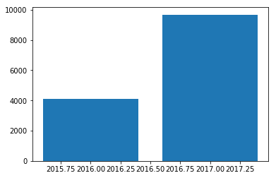

```python
import matplotlib.pyplot as plt

plt.bar(bread.year,bread.Transaction)
plt.show()
```

```python
bread.year.value_counts()
```

```
2017    12732
2016     8561
Name: year, dtype: int64
```

```python
diff_sale = len(bread[bread.year == 2017]) - len(bread[bread.year == 2016])
diff_sale
#len(bread[bread.year == 2016])/len(bread)*100.0
```

```
4171
```

```python
#Calculating the percentage increase/decrease in sales
diff_sale/len(bread[bread.year == 2016]) * 100.0
```

```
48.72094381497489
```

The percentage increase in sale from 2016 to 2017 was 48.7%.That was a significant increase so to answer the question how the company was doing, based on the increase in sale from the previous year, I think the company is doing very well.

#### How often is there a line with people waiting?

#### How fast can they do transactions? ie should they get another register?

#### Part C.Model the customer behavior?

#### Model the user behavior to help the owner. Explain why what you are doing will help the owner.

```python
bread2 = bread[['Item','Transaction','count']]
```

```python
from mlxtend.frequent_patterns import apriori
from mlxtend.frequent_patterns import association_rules
basket = (bread2
          .groupby(['Transaction','Item'])
          .sum().unstack().reset_index().fillna(0)
          .set_index('Transaction'))
```

```python
basket
```

| Item Transaction | count Adjustment | count Afternoon with the baker | count Alfajores | count Argentina Night | count Art Tray | count Bacon | count Baguette | count Bakewell | count Bare Popcorn | count Basket | count ... | count The BART | count The Nomad | count Tiffin | count Toast | count Truffles | count Tshirt | count Valentine's card | count Vegan Feast | count Vegan mincepie | count Victorian Sponge |
| --- | --- | --- | --- | --- | --- | --- | --- | --- | --- | --- | --- | --- | --- | --- | --- | --- | --- | --- | --- | --- | --- |
| 1 | 0.0 | 0.0 | 0.0 | 0.0 | 0.0 | 0.0 | 0.0 | 0.0 | 0.0 | 0.0 | ... | 0.0 | 0.0 | 0.0 | 0.0 | 0.0 | 0.0 | 0.0 | 0.0 | 0.0 | 0.0 |
| 2 | 0.0 | 0.0 | 0.0 | 0.0 | 0.0 | 0.0 | 0.0 | 0.0 | 0.0 | 0.0 | ... | 0.0 | 0.0 | 0.0 | 0.0 | 0.0 | 0.0 | 0.0 | 0.0 | 0.0 | 0.0 |
| 3 | 0.0 | 0.0 | 0.0 | 0.0 | 0.0 | 0.0 | 0.0 | 0.0 | 0.0 | 0.0 | ... | 0.0 | 0.0 | 0.0 | 0.0 | 0.0 | 0.0 | 0.0 | 0.0 | 0.0 | 0.0 |
| 4 | 0.0 | 0.0 | 0.0 | 0.0 | 0.0 | 0.0 | 0.0 | 0.0 | 0.0 | 0.0 | ... | 0.0 | 0.0 | 0.0 | 0.0 | 0.0 | 0.0 | 0.0 | 0.0 | 0.0 | 0.0 |
| 5 | 0.0 | 0.0 | 0.0 | 0.0 | 0.0 | 0.0 | 0.0 | 0.0 | 0.0 | 0.0 | ... | 0.0 | 0.0 | 0.0 | 0.0 | 0.0 | 0.0 | 0.0 | 0.0 | 0.0 | 0.0 |
| 6 | 0.0 | 0.0 | 0.0 | 0.0 | 0.0 | 0.0 | 0.0 | 0.0 | 0.0 | 0.0 | ... | 0.0 | 0.0 | 0.0 | 0.0 | 0.0 | 0.0 | 0.0 | 0.0 | 0.0 | 0.0 |
| 7 | 0.0 | 0.0 | 0.0 | 0.0 | 0.0 | 0.0 | 0.0 | 0.0 | 0.0 | 0.0 | ... | 0.0 | 0.0 | 0.0 | 0.0 | 0.0 | 0.0 | 0.0 | 0.0 | 0.0 | 0.0 |
| 8 | 0.0 | 0.0 | 0.0 | 0.0 | 0.0 | 0.0 | 0.0 | 0.0 | 0.0 | 0.0 | ... | 0.0 | 0.0 | 0.0 | 0.0 | 0.0 | 0.0 | 0.0 | 0.0 | 0.0 | 0.0 |
| 9 | 0.0 | 0.0 | 0.0 | 0.0 | 0.0 | 0.0 | 0.0 | 0.0 | 0.0 | 0.0 | ... | 0.0 | 0.0 | 0.0 | 0.0 | 0.0 | 0.0 | 0.0 | 0.0 | 0.0 | 0.0 |
| 10 | 0.0 | 0.0 | 0.0 | 0.0 | 0.0 | 0.0 | 0.0 | 0.0 | 0.0 | 0.0 | ... | 0.0 | 0.0 | 0.0 | 0.0 | 0.0 | 0.0 | 0.0 | 0.0 | 0.0 | 0.0 |
| 11 | 0.0 | 0.0 | 0.0 | 0.0 | 0.0 | 0.0 | 0.0 | 0.0 | 0.0 | 0.0 | ... | 0.0 | 0.0 | 0.0 | 0.0 | 0.0 | 0.0 | 0.0 | 0.0 | 0.0 | 0.0 |
| 12 | 0.0 | 0.0 | 0.0 | 0.0 | 0.0 | 0.0 | 0.0 | 0.0 | 0.0 | 0.0 | ... | 0.0 | 0.0 | 0.0 | 0.0 | 0.0 | 0.0 | 0.0 | 0.0 | 0.0 | 0.0 |
| 13 | 0.0 | 0.0 | 0.0 | 0.0 | 0.0 | 0.0 | 0.0 | 0.0 | 0.0 | 1.0 | ... | 0.0 | 0.0 | 0.0 | 0.0 | 0.0 | 0.0 | 0.0 | 0.0 | 0.0 | 0.0 |
| 14 | 0.0 | 0.0 | 0.0 | 0.0 | 0.0 | 0.0 | 0.0 | 0.0 | 0.0 | 0.0 | ... | 0.0 | 0.0 | 0.0 | 0.0 | 0.0 | 0.0 | 0.0 | 0.0 | 0.0 | 0.0 |
| 15 | 0.0 | 0.0 | 0.0 | 0.0 | 0.0 | 0.0 | 0.0 | 0.0 | 0.0 | 0.0 | ... | 0.0 | 0.0 | 0.0 | 0.0 | 0.0 | 0.0 | 0.0 | 0.0 | 0.0 | 0.0 |
| 16 | 0.0 | 0.0 | 0.0 | 0.0 | 0.0 | 0.0 | 0.0 | 0.0 | 0.0 | 0.0 | ... | 0.0 | 0.0 | 0.0 | 0.0 | 0.0 | 0.0 | 0.0 | 0.0 | 0.0 | 0.0 |
| 17 | 0.0 | 0.0 | 0.0 | 0.0 | 0.0 | 0.0 | 0.0 | 0.0 | 0.0 | 0.0 | ... | 0.0 | 0.0 | 0.0 | 0.0 | 0.0 | 0.0 | 0.0 | 0.0 | 0.0 | 0.0 |
| 18 | 0.0 | 0.0 | 0.0 | 0.0 | 0.0 | 0.0 | 0.0 | 0.0 | 0.0 | 0.0 | ... | 0.0 | 0.0 | 0.0 | 0.0 | 0.0 | 0.0 | 0.0 | 0.0 | 0.0 | 0.0 |
| 19 | 0.0 | 0.0 | 0.0 | 0.0 | 0.0 | 0.0 | 0.0 | 0.0 | 0.0 | 0.0 | ... | 0.0 | 0.0 | 0.0 | 0.0 | 0.0 | 0.0 | 0.0 | 0.0 | 0.0 | 0.0 |
| 20 | 0.0 | 0.0 | 0.0 | 0.0 | 0.0 | 0.0 | 0.0 | 0.0 | 0.0 | 0.0 | ... | 0.0 | 0.0 | 0.0 | 0.0 | 0.0 | 0.0 | 0.0 | 0.0 | 0.0 | 0.0 |
| 21 | 0.0 | 0.0 | 0.0 | 0.0 | 0.0 | 0.0 | 0.0 | 0.0 | 0.0 | 0.0 | ... | 0.0 | 0.0 | 0.0 | 0.0 | 0.0 | 0.0 | 0.0 | 0.0 | 0.0 | 0.0 |
| 22 | 0.0 | 0.0 | 0.0 | 0.0 | 0.0 | 0.0 | 0.0 | 0.0 | 0.0 | 0.0 | ... | 0.0 | 0.0 | 0.0 | 0.0 | 0.0 | 0.0 | 0.0 | 0.0 | 0.0 | 0.0 |
| 23 | 0.0 | 0.0 | 0.0 | 0.0 | 0.0 | 0.0 | 0.0 | 0.0 | 0.0 | 0.0 | ... | 0.0 | 0.0 | 0.0 | 0.0 | 0.0 | 0.0 | 0.0 | 0.0 | 0.0 | 0.0 |
| 24 | 0.0 | 0.0 | 0.0 | 0.0 | 0.0 | 0.0 | 0.0 | 0.0 | 0.0 | 0.0 | ... | 0.0 | 0.0 | 0.0 | 0.0 | 0.0 | 0.0 | 0.0 | 0.0 | 0.0 | 0.0 |
| 25 | 0.0 | 0.0 | 0.0 | 0.0 | 0.0 | 0.0 | 0.0 | 0.0 | 0.0 | 0.0 | ... | 0.0 | 0.0 | 0.0 | 0.0 | 0.0 | 0.0 | 0.0 | 0.0 | 0.0 | 0.0 |
| 26 | 0.0 | 0.0 | 0.0 | 0.0 | 0.0 | 0.0 | 0.0 | 0.0 | 0.0 | 0.0 | ... | 0.0 | 0.0 | 0.0 | 0.0 | 0.0 | 0.0 | 0.0 | 0.0 | 0.0 | 0.0 |
| 27 | 0.0 | 0.0 | 0.0 | 0.0 | 0.0 | 0.0 | 0.0 | 0.0 | 0.0 | 0.0 | ... | 0.0 | 0.0 | 0.0 | 0.0 | 0.0 | 0.0 | 0.0 | 0.0 | 0.0 | 0.0 |
| 28 | 0.0 | 0.0 | 0.0 | 0.0 | 0.0 | 0.0 | 0.0 | 0.0 | 0.0 | 0.0 | ... | 0.0 | 0.0 | 0.0 | 0.0 | 0.0 | 0.0 | 0.0 | 0.0 | 0.0 | 0.0 |
| 29 | 0.0 | 0.0 | 0.0 | 0.0 | 0.0 | 0.0 | 0.0 | 0.0 | 0.0 | 0.0 | ... | 0.0 | 0.0 | 0.0 | 0.0 | 0.0 | 0.0 | 0.0 | 0.0 | 0.0 | 0.0 |
| 30 | 0.0 | 0.0 | 0.0 | 0.0 | 0.0 | 0.0 | 0.0 | 0.0 | 0.0 | 0.0 | ... | 0.0 | 0.0 | 0.0 | 0.0 | 0.0 | 0.0 | 0.0 | 0.0 | 0.0 | 0.0 |
| ... | ... | ... | ... | ... | ... | ... | ... | ... | ... | ... | ... | ... | ... | ... | ... | ... | ... | ... | ... | ... | ... |
| 9651 | 0.0 | 0.0 | 0.0 | 0.0 | 0.0 | 0.0 | 0.0 | 0.0 | 0.0 | 0.0 | ... | 0.0 | 0.0 | 0.0 | 0.0 | 0.0 | 0.0 | 0.0 | 0.0 | 0.0 | 0.0 |
| 9652 | 0.0 | 0.0 | 0.0 | 0.0 | 0.0 | 0.0 | 1.0 | 0.0 | 0.0 | 0.0 | ... | 0.0 | 0.0 | 0.0 | 0.0 | 0.0 | 0.0 | 0.0 | 0.0 | 0.0 | 0.0 |
| 9653 | 0.0 | 0.0 | 0.0 | 0.0 | 0.0 | 0.0 | 0.0 | 0.0 | 0.0 | 0.0 | ... | 0.0 | 0.0 | 0.0 | 0.0 | 0.0 | 0.0 | 0.0 | 0.0 | 0.0 | 0.0 |
| 9654 | 0.0 | 0.0 | 0.0 | 0.0 | 0.0 | 0.0 | 0.0 | 0.0 | 0.0 | 0.0 | ... | 0.0 | 0.0 | 0.0 | 0.0 | 0.0 | 0.0 | 0.0 | 0.0 | 0.0 | 0.0 |
| 9655 | 0.0 | 0.0 | 0.0 | 0.0 | 0.0 | 0.0 | 0.0 | 0.0 | 0.0 | 0.0 | ... | 0.0 | 0.0 | 0.0 | 0.0 | 0.0 | 0.0 | 0.0 | 0.0 | 0.0 | 0.0 |
| 9656 | 0.0 | 0.0 | 0.0 | 0.0 | 0.0 | 0.0 | 0.0 | 0.0 | 0.0 | 0.0 | ... | 0.0 | 0.0 | 0.0 | 1.0 | 0.0 | 0.0 | 0.0 | 0.0 | 0.0 | 0.0 |
| 9657 | 0.0 | 0.0 | 0.0 | 0.0 | 0.0 | 0.0 | 0.0 | 0.0 | 0.0 | 0.0 | ... | 0.0 | 0.0 | 0.0 | 0.0 | 0.0 | 0.0 | 0.0 | 0.0 | 0.0 | 0.0 |
| 9658 | 0.0 | 0.0 | 0.0 | 0.0 | 0.0 | 0.0 | 0.0 | 0.0 | 0.0 | 0.0 | ... | 0.0 | 0.0 | 0.0 | 0.0 | 0.0 | 0.0 | 0.0 | 0.0 | 0.0 | 0.0 |
| 9659 | 0.0 | 0.0 | 0.0 | 0.0 | 0.0 | 0.0 | 0.0 | 0.0 | 0.0 | 0.0 | ... | 0.0 | 0.0 | 0.0 | 0.0 | 0.0 | 0.0 | 0.0 | 0.0 | 0.0 | 0.0 |
| 9660 | 0.0 | 0.0 | 0.0 | 0.0 | 0.0 | 0.0 | 0.0 | 0.0 | 0.0 | 0.0 | ... | 0.0 | 0.0 | 0.0 | 0.0 | 0.0 | 0.0 | 0.0 | 0.0 | 0.0 | 0.0 |
| 9664 | 0.0 | 0.0 | 0.0 | 0.0 | 0.0 | 0.0 | 0.0 | 0.0 | 0.0 | 0.0 | ... | 0.0 | 0.0 | 0.0 | 0.0 | 0.0 | 0.0 | 0.0 | 0.0 | 0.0 | 0.0 |
| 9665 | 0.0 | 0.0 | 0.0 | 0.0 | 0.0 | 0.0 | 0.0 | 0.0 | 0.0 | 0.0 | ... | 0.0 | 0.0 | 0.0 | 0.0 | 0.0 | 0.0 | 0.0 | 0.0 | 0.0 | 0.0 |
| 9666 | 0.0 | 0.0 | 0.0 | 0.0 | 0.0 | 0.0 | 0.0 | 0.0 | 0.0 | 0.0 | ... | 0.0 | 0.0 | 0.0 | 0.0 | 0.0 | 0.0 | 0.0 | 0.0 | 0.0 | 0.0 |
| 9667 | 0.0 | 0.0 | 0.0 | 0.0 | 0.0 | 0.0 | 0.0 | 0.0 | 0.0 | 0.0 | ... | 0.0 | 0.0 | 0.0 | 0.0 | 0.0 | 0.0 | 0.0 | 0.0 | 0.0 | 0.0 |
| 9668 | 0.0 | 0.0 | 0.0 | 0.0 | 0.0 | 0.0 | 0.0 | 0.0 | 0.0 | 0.0 | ... | 0.0 | 0.0 | 0.0 | 0.0 | 0.0 | 0.0 | 0.0 | 0.0 | 0.0 | 0.0 |
| 9669 | 0.0 | 0.0 | 0.0 | 0.0 | 0.0 | 0.0 | 0.0 | 0.0 | 0.0 | 0.0 | ... | 0.0 | 0.0 | 0.0 | 0.0 | 0.0 | 0.0 | 0.0 | 0.0 | 0.0 | 0.0 |
| 9670 | 0.0 | 0.0 | 0.0 | 0.0 | 0.0 | 0.0 | 0.0 | 0.0 | 0.0 | 0.0 | ... | 0.0 | 0.0 | 0.0 | 0.0 | 0.0 | 0.0 | 0.0 | 0.0 | 0.0 | 0.0 |
| 9671 | 0.0 | 0.0 | 0.0 | 0.0 | 0.0 | 0.0 | 0.0 | 0.0 | 0.0 | 0.0 | ... | 0.0 | 0.0 | 0.0 | 0.0 | 0.0 | 0.0 | 0.0 | 0.0 | 0.0 | 0.0 |
| 9672 | 0.0 | 0.0 | 0.0 | 0.0 | 0.0 | 0.0 | 0.0 | 0.0 | 0.0 | 0.0 | ... | 0.0 | 0.0 | 0.0 | 0.0 | 0.0 | 0.0 | 0.0 | 0.0 | 0.0 | 0.0 |
| 9673 | 0.0 | 0.0 | 0.0 | 0.0 | 0.0 | 0.0 | 0.0 | 0.0 | 0.0 | 0.0 | ... | 0.0 | 0.0 | 0.0 | 0.0 | 0.0 | 0.0 | 0.0 | 0.0 | 0.0 | 0.0 |
| 9674 | 0.0 | 0.0 | 0.0 | 0.0 | 0.0 | 0.0 | 0.0 | 0.0 | 0.0 | 0.0 | ... | 0.0 | 0.0 | 0.0 | 0.0 | 0.0 | 0.0 | 0.0 | 0.0 | 0.0 | 0.0 |
| 9676 | 0.0 | 0.0 | 0.0 | 0.0 | 0.0 | 0.0 | 0.0 | 0.0 | 0.0 | 0.0 | ... | 0.0 | 0.0 | 0.0 | 0.0 | 0.0 | 0.0 | 0.0 | 0.0 | 0.0 | 0.0 |
| 9677 | 0.0 | 0.0 | 0.0 | 0.0 | 0.0 | 0.0 | 0.0 | 0.0 | 0.0 | 0.0 | ... | 0.0 | 0.0 | 0.0 | 0.0 | 0.0 | 0.0 | 0.0 | 0.0 | 0.0 | 0.0 |
| 9678 | 0.0 | 0.0 | 0.0 | 0.0 | 0.0 | 0.0 | 0.0 | 0.0 | 0.0 | 0.0 | ... | 0.0 | 0.0 | 0.0 | 1.0 | 0.0 | 0.0 | 0.0 | 0.0 | 0.0 | 0.0 |
| 9679 | 0.0 | 0.0 | 0.0 | 0.0 | 0.0 | 0.0 | 0.0 | 0.0 | 0.0 | 0.0 | ... | 0.0 | 0.0 | 0.0 | 0.0 | 0.0 | 0.0 | 0.0 | 0.0 | 0.0 | 0.0 |
| 9680 | 0.0 | 0.0 | 0.0 | 0.0 | 0.0 | 0.0 | 0.0 | 0.0 | 0.0 | 0.0 | ... | 0.0 | 0.0 | 0.0 | 0.0 | 0.0 | 0.0 | 0.0 | 0.0 | 0.0 | 0.0 |
| 9681 | 0.0 | 0.0 | 0.0 | 0.0 | 0.0 | 0.0 | 0.0 | 0.0 | 0.0 | 0.0 | ... | 0.0 | 0.0 | 0.0 | 0.0 | 1.0 | 0.0 | 0.0 | 0.0 | 0.0 | 0.0 |
| 9682 | 0.0 | 0.0 | 0.0 | 0.0 | 0.0 | 0.0 | 0.0 | 0.0 | 0.0 | 0.0 | ... | 0.0 | 0.0 | 0.0 | 0.0 | 0.0 | 0.0 | 0.0 | 0.0 | 0.0 | 0.0 |
| 9683 | 0.0 | 0.0 | 0.0 | 0.0 | 0.0 | 0.0 | 0.0 | 0.0 | 0.0 | 0.0 | ... | 0.0 | 0.0 | 0.0 | 0.0 | 0.0 | 0.0 | 0.0 | 0.0 | 0.0 | 0.0 |
| 9684 | 0.0 | 0.0 | 0.0 | 0.0 | 0.0 | 0.0 | 0.0 | 0.0 | 0.0 | 0.0 | ... | 0.0 | 0.0 | 0.0 | 0.0 | 0.0 | 0.0 | 0.0 | 0.0 | 0.0 | 0.0 |

9531 rows × 95 columns

```python
def encode_units(x):
    if x <= 0:
        return 0
    if x >= 1:
        return 1

basket_sets = basket.applymap(encode_units)
#basket_sets.drop('NONE', inplace=True, axis=1)
```

```python
frequent_itemsets = apriori(basket_sets, min_support=0.007, use_colnames=True)
```

```python
frequent_itemsets
```

|  | support | itemsets |
| --- | --- | --- |
| 0 | 0.036093 | ((count, Alfajores)) |
| 1 | 0.015948 | ((count, Baguette)) |
| 2 | 0.324940 | ((count, Bread)) |
| 3 | 0.039765 | ((count, Brownie)) |
| 4 | 0.103137 | ((count, Cake)) |
| 5 | 0.012905 | ((count, Chicken Stew)) |
| 6 | 0.475081 | ((count, Coffee)) |
| 7 | 0.019305 | ((count, Coke)) |
| 8 | 0.054034 | ((count, Cookies)) |
| 9 | 0.038926 | ((count, Farm House)) |
| 10 | 0.008499 | ((count, Frittata)) |
| 11 | 0.014899 | ((count, Fudge)) |
| 12 | 0.010492 | ((count, Hearty & Seasonal)) |
| 13 | 0.057916 | ((count, Hot chocolate)) |
| 14 | 0.014899 | ((count, Jam)) |
| 15 | 0.013115 | ((count, Jammie Dodgers)) |
| 16 | 0.038296 | ((count, Juice)) |
| 17 | 0.061379 | ((count, Medialuna)) |
| 18 | 0.014059 | ((count, Mineral water)) |
| 19 | 0.038191 | ((count, Muffin)) |
| 20 | 0.079005 | ((count, NONE)) |
| 21 | 0.085510 | ((count, Pastry)) |
| 22 | 0.010387 | ((count, Salad)) |
| 23 | 0.071346 | ((count, Sandwich)) |
| 24 | 0.028853 | ((count, Scandinavian)) |
| 25 | 0.034309 | ((count, Scone)) |
| 26 | 0.008079 | ((count, Smoothies)) |
| 27 | 0.034204 | ((count, Soup)) |
| 28 | 0.018046 | ((count, Spanish Brunch)) |
| 29 | 0.141643 | ((count, Tea)) |
| ... | ... | ... |
| 57 | 0.020460 | ((count, Coffee), (count, Juice)) |
| 58 | 0.034939 | ((count, Coffee), (count, Medialuna)) |
| 59 | 0.018676 | ((count, Muffin), (count, Coffee)) |
| 60 | 0.042073 | ((count, Coffee), (count, NONE)) |
| 61 | 0.047214 | ((count, Coffee), (count, Pastry)) |
| 62 | 0.037981 | ((count, Sandwich), (count, Coffee)) |
| 63 | 0.017941 | ((count, Scone), (count, Coffee)) |
| 64 | 0.015738 | ((count, Coffee), (count, Soup)) |
| 65 | 0.010807 | ((count, Spanish Brunch), (count, Coffee)) |
| 66 | 0.049523 | ((count, Tea), (count, Coffee)) |
| 67 | 0.008394 | ((count, Tiffin), (count, Coffee)) |
| 68 | 0.023502 | ((count, Toast), (count, Coffee)) |
| 69 | 0.007449 | ((count, Coffee), (count, Truffles)) |
| 70 | 0.009758 | ((count, Tea), (count, Cookies)) |
| 71 | 0.007974 | ((count, Tea), (count, Hot chocolate)) |
| 72 | 0.007135 | ((count, Tea), (count, Juice)) |
| 73 | 0.009128 | ((count, Pastry), (count, Medialuna)) |
| 74 | 0.008079 | ((count, Tea), (count, Medialuna)) |
| 75 | 0.009128 | ((count, Sandwich), (count, NONE)) |
| 76 | 0.018256 | ((count, Tea), (count, NONE)) |
| 77 | 0.009548 | ((count, Tea), (count, Pastry)) |
| 78 | 0.014269 | ((count, Tea), (count, Sandwich)) |
| 79 | 0.008289 | ((count, Scone), (count, Tea)) |
| 80 | 0.009023 | ((count, Tea), (count, Soup)) |
| 81 | 0.009967 | ((count, Coffee), (count, Cake), (count, Bread)) |
| 82 | 0.008394 | ((count, Coffee), (count, NONE), (count, Bread)) |
| 83 | 0.011122 | ((count, Coffee), (count, Pastry), (count, Bre... |
| 84 | 0.007135 | ((count, Sandwich), (count, Coffee), (count, B... |
| 85 | 0.007344 | ((count, Tea), (count, Coffee), (count, Bread)) |
| 86 | 0.009967 | ((count, Tea), (count, Coffee), (count, Cake)) |

87 rows × 2 columns

```python
rules = association_rules(frequent_itemsets, metric="lift", min_threshold=1)
rules.head()
```

|  | antecedents | consequents | antecedent support | consequent support | support | confidence | lift | leverage | conviction |
| --- | --- | --- | --- | --- | --- | --- | --- | --- | --- |
| 0 | ((count, Coffee)) | ((count, Alfajores)) | 0.475081 | 0.036093 | 0.019515 | 0.041078 | 1.138116 | 0.002368 | 1.005199 |
| 1 | ((count, Alfajores)) | ((count, Coffee)) | 0.036093 | 0.475081 | 0.019515 | 0.540698 | 1.138116 | 0.002368 | 1.142861 |
| 2 | ((count, Pastry)) | ((count, Bread)) | 0.085510 | 0.324940 | 0.028958 | 0.338650 | 1.042194 | 0.001172 | 1.020731 |
| 3 | ((count, Bread)) | ((count, Pastry)) | 0.324940 | 0.085510 | 0.028958 | 0.089119 | 1.042194 | 0.001172 | 1.003961 |
| 4 | ((count, Brownie)) | ((count, Coffee)) | 0.039765 | 0.475081 | 0.019515 | 0.490765 | 1.033013 | 0.000624 | 1.030799 |

```python
rules[ (rules['lift'] >= 1.0) &
       (rules['confidence'] >= 0.5) ]
```

|  | antecedents | consequents | antecedent support | consequent support | support | confidence | lift | leverage | conviction |
| --- | --- | --- | --- | --- | --- | --- | --- | --- | --- |
| 1 | ((count, Alfajores)) | ((count, Coffee)) | 0.036093 | 0.475081 | 0.019515 | 0.540698 | 1.138116 | 0.002368 | 1.142861 |
| 7 | ((count, Cake)) | ((count, Coffee)) | 0.103137 | 0.475081 | 0.054349 | 0.526958 | 1.109196 | 0.005350 | 1.109667 |
| 17 | ((count, Cookies)) | ((count, Coffee)) | 0.054034 | 0.475081 | 0.028014 | 0.518447 | 1.091280 | 0.002343 | 1.090053 |
| 18 | ((count, Hot chocolate)) | ((count, Coffee)) | 0.057916 | 0.475081 | 0.029378 | 0.507246 | 1.067704 | 0.001863 | 1.065276 |
| 21 | ((count, Juice)) | ((count, Coffee)) | 0.038296 | 0.475081 | 0.020460 | 0.534247 | 1.124537 | 0.002266 | 1.127031 |
| 23 | ((count, Medialuna)) | ((count, Coffee)) | 0.061379 | 0.475081 | 0.034939 | 0.569231 | 1.198175 | 0.005779 | 1.218561 |
| 27 | ((count, NONE)) | ((count, Coffee)) | 0.079005 | 0.475081 | 0.042073 | 0.532537 | 1.120938 | 0.004539 | 1.122908 |
| 29 | ((count, Pastry)) | ((count, Coffee)) | 0.085510 | 0.475081 | 0.047214 | 0.552147 | 1.162216 | 0.006590 | 1.172079 |
| 30 | ((count, Sandwich)) | ((count, Coffee)) | 0.071346 | 0.475081 | 0.037981 | 0.532353 | 1.120551 | 0.004086 | 1.122468 |
| 32 | ((count, Scone)) | ((count, Coffee)) | 0.034309 | 0.475081 | 0.017941 | 0.522936 | 1.100729 | 0.001642 | 1.100310 |
| 34 | ((count, Spanish Brunch)) | ((count, Coffee)) | 0.018046 | 0.475081 | 0.010807 | 0.598837 | 1.260494 | 0.002233 | 1.308493 |
| 36 | ((count, Tiffin)) | ((count, Coffee)) | 0.015318 | 0.475081 | 0.008394 | 0.547945 | 1.153371 | 0.001116 | 1.161184 |
| 38 | ((count, Toast)) | ((count, Coffee)) | 0.033365 | 0.475081 | 0.023502 | 0.704403 | 1.482699 | 0.007651 | 1.775789 |

```python
#basket.describe()
```

Market basket analysis is an appropriate modeling technique I explored to be able to help the bakey owner. Association rule analysis gives us insights as to which items can be paired together to hopefully boast sales. Assocition analysis is used to find interesting patterns or combinations.

- Analysis Results

  ```
     Results shows that some of the frequent items that were bought together and should be packaged together to be sold are:
         Coffee and Toast
         Coffee and Tiffin
         Coffee and Spanish Brunch
         Coffee and Scone
         Coffee and Sandwich
         Coffee and Pastry
         Coffee and Medialuna
         Coffee and Juice
         Coffee and Hot Chocolate
         Coffee and Cookies
         Coffee and Cake
         Coffee and Alfajores
  ```

For the association rule analysis the based on confidence, the result with the best pairing was "Toast" and "Coffe" followed by "Spanish Brunch" and "Coffee". The result with the least confidence greater than 50% by the way was "Hot Chocolate" and "Coffee".

#### They run out of coffee after 500 cups. They want to get it at the last possible minute so its fresh. But it takes 3 days to arrive. When should they order?

http://pbpython.com/market-basket-analysis.html